# Práctico 1 - Estadística

## Consigna 1

> En estadística una población es un conjunto de sujetos, individuos, elementos o eventos con determinadas características. – Fuente: Wikipedia

> En estadística, una muestra es un subconjunto de casos o individuos de una población. – Fuente: Wikipedia

**Respuesta 1**: Es una muestra. Ya que la población es el conjunto de empresas de Río Cuarto censadas (censo=totalidad) en el año 2007

**Respuesta 2**: Es una muestra. Ya que el filtro de la selección se define como “principales”. Distinto hubiese sido si su hubiera definido, las empresas Químicas de Río Cuarto. En este último caso sabemos que son todas que tiene dicha actividad.

## Tabla de Datos

```r
load('datos.RData')
datos
```

| Empresa | Ventas | Insumos | Materia Prima | Gastos | Activo | Pasivo | Actividad | Empleo |
| --- | --- | --- | --- | --- | --- | --- | --- | --- |
| 27 | 77493920 | 30314091 | 38045414 | 8993486 | 61029293 | 14759644 | Alimentos | 162 |
| 44 | 22191193 | 18905188 | 11872288 | 1909105 | 5535895 | 2340818 | Maquinaria | 20 |
| 25 | 11200000 | 6060000 | 5558560 | 5486000 | 4900000 | 3175000 | Alimentos | 102 |
| 28 | 9442215 | 1133066 | 5604863 | 749749 | 3415089 | 10016110 | Maquinaria | 87 |
| 19 | 5848392 | 3864210 | 2902557 | 1672247 | 1959555 | 650374 | Alimentos | 41 |
| 36 | 5483673 | 1954929 | 3226492 | 978929 | 3928637 | 2707698 | Alimentos | 62 |
| 39 | 4225118 | 950300 | 2102841 | 1450296 | 2092192 | 1319592 | Alimentos | 37 |
| 31 | 3564877 | 855329 | 1995769 | 977444 | 721398 | 334725 | Alimentos | 37 |
| 46 | 3433927 | 1844706 | 2627437 | 256403 | 884597 | 168231 | Químicos | 25 |
| 40 | 2990823 | 358899 | 1445971 | 1138044 | 85606 | 489029 | Maquinaria | 27 |

[output cut: 10 more lines]

## Consigna 2

```r
mVentas <- mean(datos$Ventas)
mActivo <- mean(datos$Activo)
mPasivo <- mean(datos$Pasivo)
mEmpleo <- mean(datos$Empleo)
```

Media de Ventas = 8191174.2615

Media de Activo = 5472813.2715

Media de Pasivo = 1912996.2115

Media de Empleo = 41.25

## Consigna 3

```r
a3 <- table(datos$Actividad)
a3p <- prop.table(a3)
pactAlimentos <- a3p[1] * 100
pactMadera <- a3p[2] * 100
pactMaquinaria <- a3p[3] * 100
pactMetal <- a3p[4] * 100
pactPNC <- a3p[5] * 100
nactPNC <- a3["PNC"]
```

Porcentaje de Empresas de Avtidad Alimentos: 45 %

Total de Empresasa de Actividad PNC: 3

Porcentaje de Empresas de Actidad PNC: 15 %

## Consigna 4

** Gráfico de Barras**

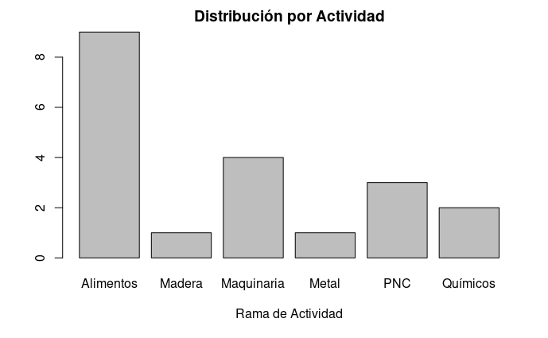

```r
counts <- table(datos$Actividad)
barplot(counts, main="Distribución por Actividad", xlab = "Rama de Actividad")
```

**Gráfico de Torta o de Sectores**

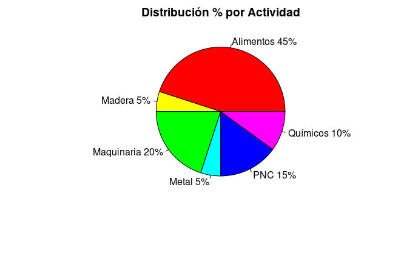

```r
mytable <- table(datos$Actividad)
lbls <- paste(names(mytable), " ", mytable/sum(mytable)*100, sep="") #Contruir porcentaje
lbls <- paste(lbls,"%",sep="") # ad % to labels  #Añadir Porcentaje
pie(mytable, labels = lbls,col=rainbow(length(lbls)), main="Distribución % por Actividad")
```

## Consigna 5

Frecuencias de la variable Actividad

```r
x = datos$Actividad
cbind(Frecuencia = table(x), Frecuencia_Acumulada = cumsum(table(x)), Frecuencia_Relativa = table(x) / length(x), Frecuencia_Relativa_Acumulada = cumsum(table(x) / length(x)) , Frecuencia_Porcentual = table(x) / length(x) * 100, Frecuencia_Porcentual_Acumulada = cumsum(table(x) / length(x) * 100) )
```

```
           Frecuencia Frecuencia_Acumulada Frecuencia_Relativa
Alimentos           9                    9                0.45
Madera              1                   10                0.05
Maquinaria          4                   14                0.20
Metal               1                   15                0.05
PNC                 3                   18                0.15
Químicos            2                   20                0.10
           Frecuencia_Relativa_Acumulada Frecuencia_Porcentual
Alimentos                           0.45                    45
Madera                              0.50                     5
Maquinaria                          0.70                    20
Metal                               0.75                     5
PNC                                 0.90                    15
Químicos                            1.00                    10
           Frecuencia_Porcentual_Acumulada
Alimentos                               45
Madera                                  50
Maquinaria                              70
Metal                                   75
PNC                                     90
Químicos                               100
```